# FE8828 Assignment 3B: Exploratory Data Analysis

Chen Jianguang Kevin

10/4/2019

# Finding #1

This bank wants to know Level 1 (External) information on the data set. The data contains 4521 observations and 17 variables.

# Finding #2

This bank wants to know Level 2 (Internal) information on the data set. The total bank balance is $6431836, the median bank balance is $444 and the average bank balance is $1422.66.

# Finding #3

The bank wants to decide how to segment different banking tiers (Retail, Premier, Treasures) based on existing clients’ bank balances. After analysis, the bank sees core concentration of bank balances below $30,000. As such, the bank decided to set Treasures Banking as >$20K, Premier Banking as >$10K and Retail Banking as <=$10K.

```r
bank %>%
 group_by(bal_grp = (balance %/% 1000) * 1000) %>%
 summarise(count = n()) %>%
 arrange(bal_grp) -> banktier
banktier
```

```
## # A tibble: 33 x 2
##    bal_grp count
##      <dbl> <int>
##  1   -4000     1
##  2   -3000     1
##  3   -2000    12
##  4   -1000   352
##  5       0  2674
##  6    1000   594
##  7    2000   268
##  8    3000   186
##  9    4000   124
## 10    5000    75
## # ... with 23 more rows
```

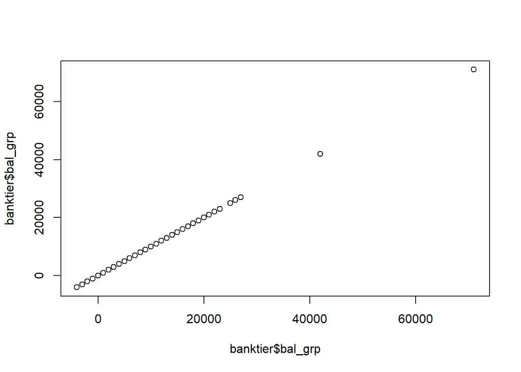

```r
plot(banktier$bal_grp, banktier$bal_grp)
```

# Finding #4

The bank wants to find out which three jobs poses the highest default risk, so the bank can create more stringent credit checks on loan applications from these individuals in future. After analysis, they are entrepreneurs (4.17%), self-employed (2.19%) and unemployed (2.34%).

```r
bank %>%
 group_by(job) %>%
 summarise(count = n(),
           default_count = sum(ifelse(default == "no", 0, 1)),
           default_ratio = default_count * 100 / count) %>%
            arrange(job) -> defaultconc
defaultconc
```

```
## # A tibble: 12 x 4
##    job           count default_count default_ratio
##    <fct>         <int>         <dbl>         <dbl>
##  1 admin.          478             6          1.26
##  2 blue-collar     946            14          1.48
##  3 entrepreneur    168             7          4.17
##  4 housemaid       112             2          1.79
##  5 management      969            14          1.44
##  6 retired         230             3          1.30
##  7 self-employed   183             4          2.19
##  8 services        417             7          1.68
##  9 student          84             1          1.19
## 10 technician      768            15          1.95
## 11 unemployed      128             3          2.34
## 12 unknown          38             0          0
```

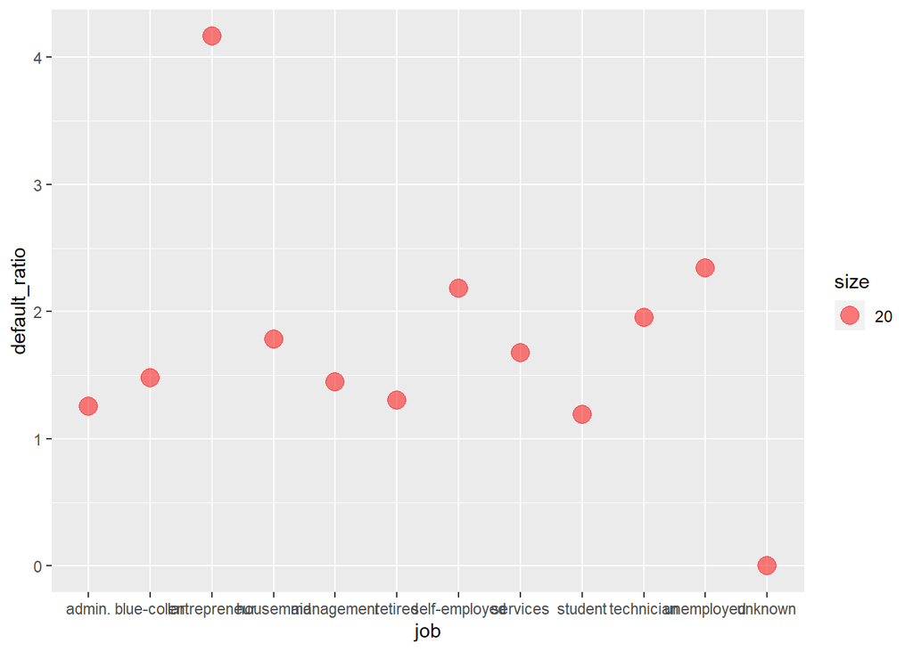

```r
defaultconc %>%
ggplot(aes(x = job, y = default_ratio)) +
  geom_point(aes(size = 20), alpha = 1/2, color = "red")
```

# Finding #5

The bank wants to find out whether it is feasible to launch a campaign based on marital status and housing loans. In particular, the bank also wants to focus on different marital status and those with houses but no loans.

```r
df1 <- group_by(bank, marital) %>%
  summarise(`With housing` = sum(housing=="yes"))
df2 <- group_by(bank, marital) %>%
  summarise(`Without loan` = sum(loan=="no"))
df3 <- group_by(bank, marital) %>%
  summarise(`With house and no loan` = sum(housing=="yes" & loan=="no"))
df4 <- left_join (df1, df2, by = "marital")
df <- left_join (df4, df3, by = "marital")
df
```

```
## # A tibble: 3 x 4
##   marital  `With housing` `Without loan` `With house and no loan`
##   <fct>             <int>          <int>                    <int>
## 1 divorced            298            438                      253
## 2 married            1625           2344                     1345
## 3 single              636           1048                      555
```

# Finding #6

The bank is planning to create a programme to cater to clients with the highest balances. The bank needs to first understand what is the maximum balance for each occupation before customizing this programme.

```r
df <- group_by(bank, job) %>%
  filter(balance == max(balance))
df
```

```
## # A tibble: 12 x 17
## # Groups:   job [12]
##      age job   marital education default balance housing loan  contact
##    <int> <fct> <fct>   <fct>     <fct>     <int> <fct>   <fct> <fct>
##  1    28 stud~ single  secondary no        11555 no      no    cellul~
##  2    31 hous~ single  primary   no        26965 no      no    cellul~
##  3    67 blue~ married secondary no        16353 no      no    cellul~
##  4    36 unem~ single  tertiary  no         9019 yes     no    unknown
##  5    43 tech~ single  tertiary  no        27733 yes     no    unknown
##  6    36 mana~ married tertiary  no        27359 yes     no    unknown
##  7    36 self~ married tertiary  no        16430 yes     no    unknown
##  8    42 entr~ married tertiary  no        42045 no      no    cellul~
##  9    50 serv~ married secondary no        26394 no      no    cellul~
## 10    29 admi~ married secondary no        22171 yes     no    cellul~
## 11    60 reti~ married primary   no        71188 no      no    cellul~
## 12    60 unkn~ married unknown   no         7337 no      no    cellul~
## # ... with 8 more variables: day <int>, month <fct>, duration <int>,
## #   campaign <int>, pdays <int>, previous <int>, poutcome <fct>, y <fct>
```

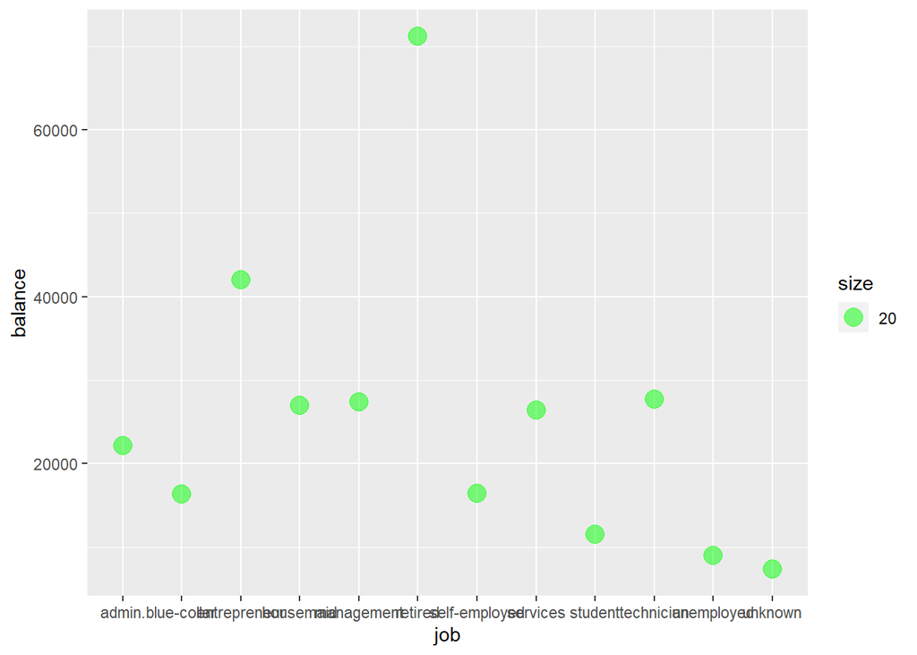

```r
df %>%
ggplot(aes(x = job, y = balance)) +
  geom_point(aes(size = 20), alpha = 1/2, color = "green")
```

# Finding #7

The bank wants to understands who are its most loyal clients (has been with the bank for at least 2 years). Then it can create a long-term campaign to target these loyal clients with less fear of them leaving the bank. After analysis, it finds out that they are the blue collar (68), management (53) and technician (37).

```r
df <- bank%>%
  group_by(job) %>%
  summarize (`No. Of Loyal Clients` = sum(duration > 2*365))
df
```

```
## # A tibble: 12 x 2
##    job           `No. Of Loyal Clients`
##    <fct>                          <int>
##  1 admin.                            20
##  2 blue-collar                       68
##  3 entrepreneur                      12
##  4 housemaid                          6
##  5 management                        53
##  6 retired                           13
##  7 self-employed                     12
##  8 services                          27
##  9 student                            3
## 10 technician                        37
## 11 unemployed                         9
## 12 unknown                            2
```

# Finding #8

The management team is very busy and just wants a quick overview on existing bank balances. As such, the balances are split into 8 quantiles and each quantile is identified with its median value.

```r
df <- group_by(bank, quantile = ntile(balance, 8)) %>%
  summarise(Median_Of_Segment = median(balance))
df
```

```
## # A tibble: 8 x 2
##   quantile Median_Of_Segment
##      <int>             <dbl>
## 1        1               -73
## 2        2                13
## 3        3               145
## 4        4               326
## 5        5               607
## 6        6              1070
## 7        7              2145
## 8        8              5291
```

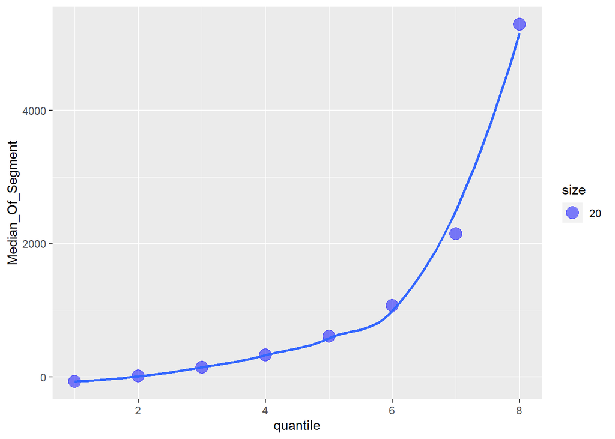

```r
df %>%
ggplot(aes(x = quantile, y = Median_Of_Segment)) +
  geom_point(aes(size = 20), alpha = 1/2, color = "blue") +
  geom_smooth(se=FALSE)
## `geom_smooth()` using method = 'loess' and formula 'y ~ x'
```

# Finding #9

The bank is thinking of launching a massive bank-wide campaign. It wants to find out which occupation coupled with a particular marital status would have the highest mean balance. The bank also wants to know the median age of a client in such a particular segment so that it can customize its campaign benefits.

```r
bank_summary <- function(frame1) {
  frame1 %>%
    group_by(job, marital) %>%
    summarise(median_of_age = median(age), mean_of_balance = mean(balance)) %>%
    ungroup() %>%
    mutate_if(is.factor, as.character)
}
frame2 <- bank %>%
  bank_summary()
frame3 <- bank %>%
  mutate(marital = "+") %>%
  bank_summary()
frame4 <- bank %>%
  mutate(marital = "+", job = "+") %>%
  bank_summary()
frame5 <- bind_rows(frame2, frame3, frame4)
frame5
```

```
## # A tibble: 48 x 4
##    job          marital  median_of_age mean_of_balance
##    <chr>        <chr>            <dbl>           <dbl>
##  1 admin.       divorced            42            978.
##  2 admin.       married             41           1353.
##  3 admin.       single              33           1111.
##  4 blue-collar  divorced            43            745.
##  5 blue-collar  married             41           1064.
##  6 blue-collar  single              32           1323.
##  7 entrepreneur divorced            49            890.
##  8 entrepreneur married             42           1613.
##  9 entrepreneur single              32           2463.
## 10 housemaid    divorced            50           1166.
## # ... with 38 more rows
```

# Finding #10

The bank wants to create a special campaign for loans. It wants to target the occupation with the most number of people with no existing loans (Management (849), Blue-collar(790)) by offering special low interest rate packages. The bank also wants to target the occupation with the most number of people with existing loans (Blue-collar (156), Management (120))so that it can come up with special refinancing rates to ensure these clients do not leave the bank.

```r
df1 <- group_by(bank, job) %>%
  summarize(withloan = sum(ifelse(loan == "yes", 1, 0)),
            noloan = sum(ifelse(loan == "no", 1, 0)))
df2 <- gather(df1, loan_or_noloan, cases , -job) %>%
        arrange(desc(cases), loan_or_noloan, job)
df2
```

```
## # A tibble: 24 x 3
##    job           loan_or_noloan cases
##    <fct>         <chr>          <dbl>
##  1 management    noloan           849
##  2 blue-collar   noloan           790
##  3 technician    noloan           649
##  4 admin.        noloan           387
##  5 services      noloan           343
##  6 retired       noloan           198
##  7 blue-collar   withloan         156
##  8 self-employed noloan           153
##  9 entrepreneur  noloan           127
## 10 management    withloan         120
## # ... with 14 more rows
```